# Proteomics Analysis

Joeri Jongbloets, Hugo Pineda

March 05 2020

## Exercise 1: Preparation

In the `load_data` chunk we need to load all the data we will need for the analysis. We have 3 data sources:

- `design`: maps sample_ids to the conditions of the experiment
- `proteomics`: contains the observed ratio’s for all proteins.
- `gene_id_map`: maps uniprot IDs to gene IDs

The data is stored respectively in 3 data.frames: `df.design`, `df.proteomics.raw`, and `df.gene.map`.

### Exercise 1.1

First thing to do when encountering a new dataset is to look at it’s shape and properties.

```
## Observations: 679
## Variables: 8
## $ protein     <chr> "P74464", "Q55901", "Q55680", "P73300", "P73111", "Q59977…
## $ description <chr> "P74464_SYNY3 General secretion pathway protein F OS=Syne…
## $ log_ratio_1 <dbl> NA, NA, NA, NA, NA, NA, NA, NA, NA, NA, NA, NA, NA, NA, N…
## $ log_ratio_2 <dbl> NA, NA, NA, NA, NA, NA, NA, NA, NA, NA, NA, NA, NA, NA, N…
## $ log_ratio_3 <dbl> NA, NA, NA, NA, NA, NA, NA, NA, NA, NA, NA, NA, NA, NA, N…
## $ avg_ratio   <dbl> NA, NA, NA, NA, NA, NA, NA, NA, NA, NA, NA, NA, NA, NA, N…
## $ sd_ratio    <dbl> NA, NA, NA, NA, NA, NA, NA, NA, NA, NA, NA, NA, NA, NA, N…
## $ ratio_count <dbl> 0, 0, 0, 0, 0, 0, 0, 0, 0, 0, 0, 0, 0, 0, 0, 0, 0, 0, 0, …
```

#### Question 1.1

What is in data.frame and what do you think is the meaning of each column? Is the data in a tidy format?

### Exercise 1.2

The second thing to check is number of NA (Not Available) values. Missing data might disrupt our analysis and many functions (like `mean`) will choke on them. To get an idea on the number of NA values we can count how many proteins have 1, 2, …, N missing values.

Create a data.frame named `df.proteomics.summary` with this summary using the `count` function of `dplyr`. This function will count the number of entries in every group and store the count in the column named `n`. Of course this means `count` only works if the data.frame is grouped (so find a column to group by!).

Using the summarized data create two bar plots. The first shows the *number* of proteins with 0, 1, .. N number of non-NA ratios and the second shows the *percentage* of proteins with 0, …, N non-NA ratios.

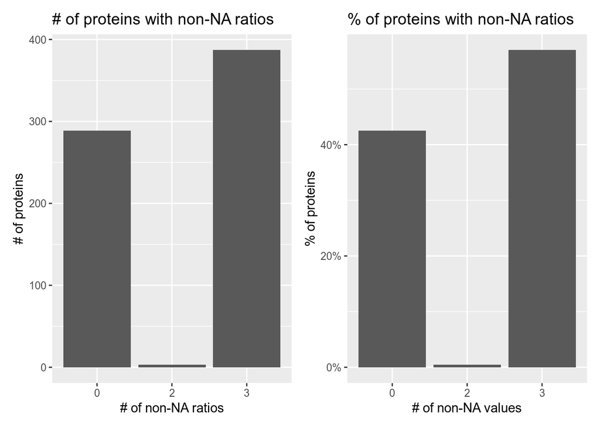

#### Question 1.2

Are proteins with 0 non-NA values useful? Should we remove them?

### Exercise 1.3

We can remove the observations for which no non-NA values are by filtering the `ratio_count` variable. At the same time this is a good oppertunity to tidy our dataset using `pivot_longer`.

## Exercise 2: Distribution of ratios

Generally it is a good idea to look at the distribution of our values and compare the distributions of across our samples.

### Exercise 2.1

Create two density plots using `geom_density` to show the overall distribution of the `avg_ratio` and the distributions of the `ratio` per replicate.

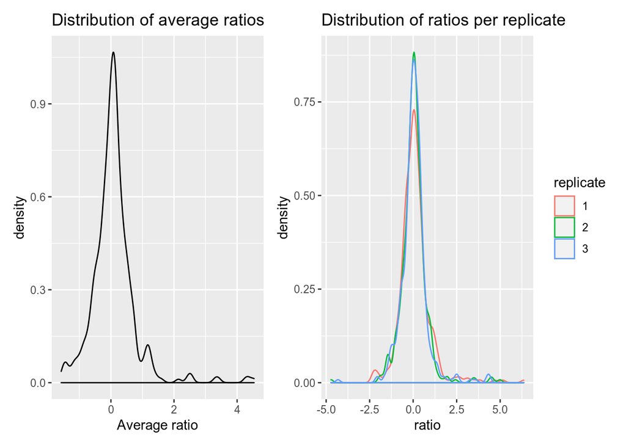

### Exercise 2.2

The (semi-)obviuous question to ask is whether our the average ratios follow a normal distribution. To assess this make a Quantile-Quantile plot (`qq`) using `stat_qq` and `stat_qq_line`.

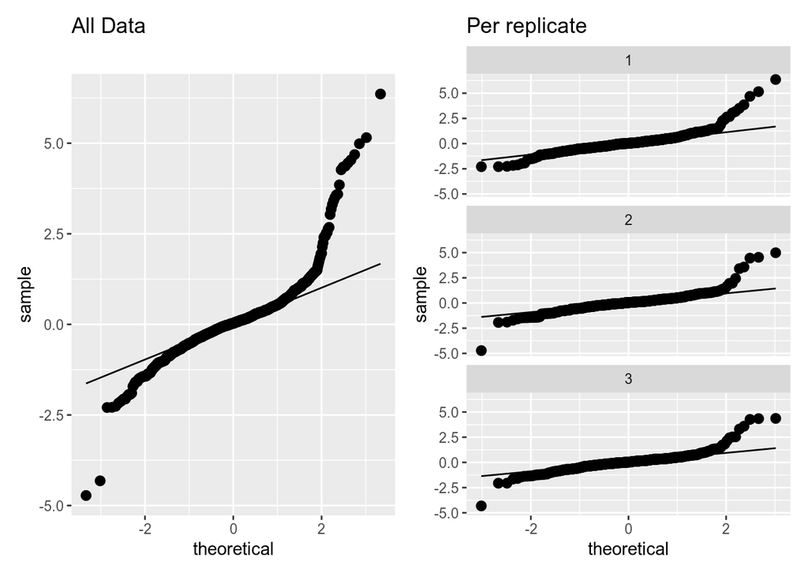

## Exercise 3: T-tests

### Exercise 3.1

As a first indication let’s use a one-sample t-test to see which proteins are significantly up/down regulated. We want to apply our t.test per protein, this means:

1. Divide the data in smaller subsets per protein (`nest`)
2. Apply `t.test` to each subset (`map`)
3. Extract model components to separate columns (`tidy`)

Since we are doing many t.tests we probably want to correct for multiple testing and flag the proteins which are significantly different from 0.

### Exercise 3.2

When performing many tests it is a good idea to look at the distribution of the p-values.

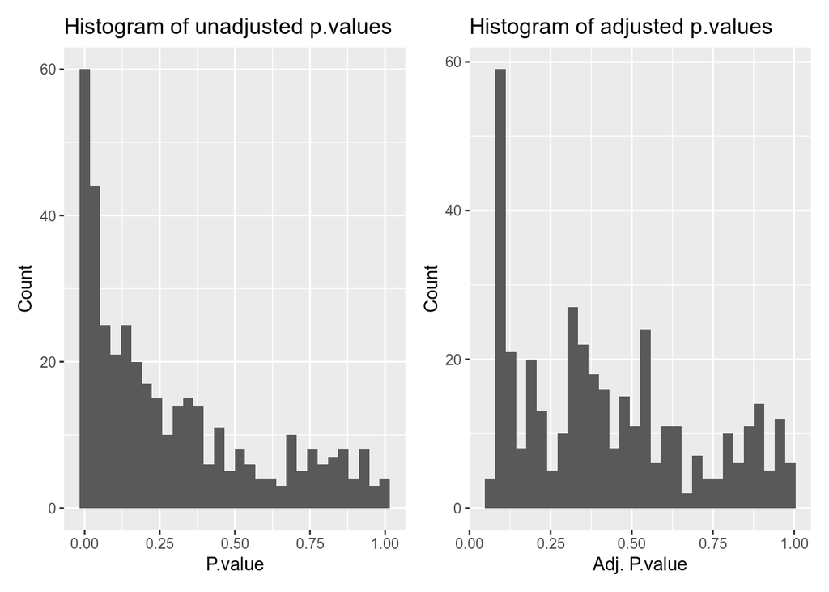

Read this if you do not know what to expect from above plot: http://varianceexplained.org/statistics/interpreting-pvalue-histogram/

### Exercise 3.3

As seen before a good method for obtaining an overview of the t.test is results is with an volcano plot.

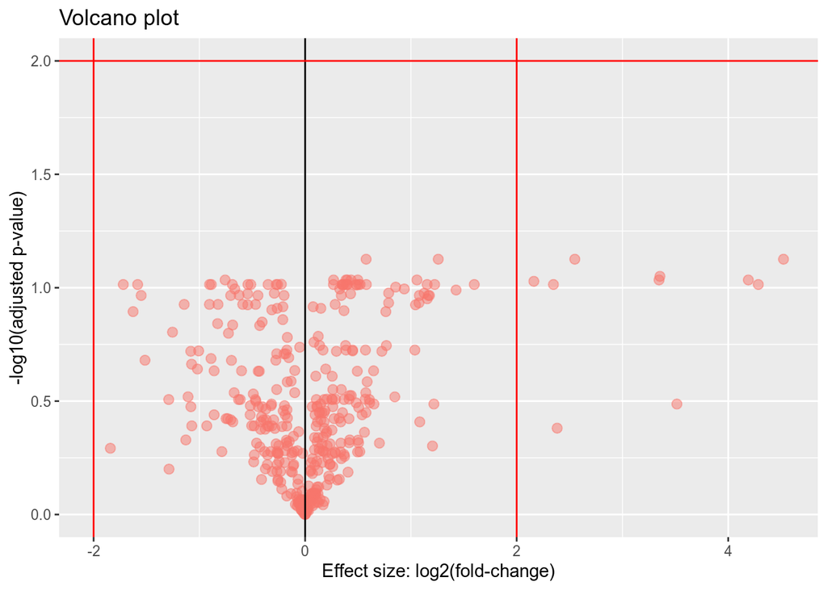

### Exercise 3.4

Finally print a table with all interesting proteins.

Proteins with adj P-value < 0.01 and absolute log ratio > 2

| protein | logFC | p.value | padj |
| --- | --- | --- | --- |

## Exercise 4: Limma

Another - more robust - method of finding which proteins are significantly up/down- regulated is using the `limma` package. The `limma` package was initially developed for (two-color) microarray data. One characteristic of this type of data is that it gives you ratios between control over treatment per gene for every replicate. This is very similar to our data!

Resources:

- https://link.springer.com/chapter/10.1007/0-387-29362-0_23
  - https://academic.oup.com/nar/article/43/7/e47/2414268

### Exercise 4.1

First create a matrix with one column per sample and one row per protein and the observed ratio as values. To retain the protein information (which can not be stored in the matrix) you can place that information in the row names. Then we can use `lmFit` to fit linear models to each protein and `eBayes` to compute statistical values for each model.

Extract the results using `topTable` (Hint set number of values to extract to Infinite) and recover the protein names from the rownames.

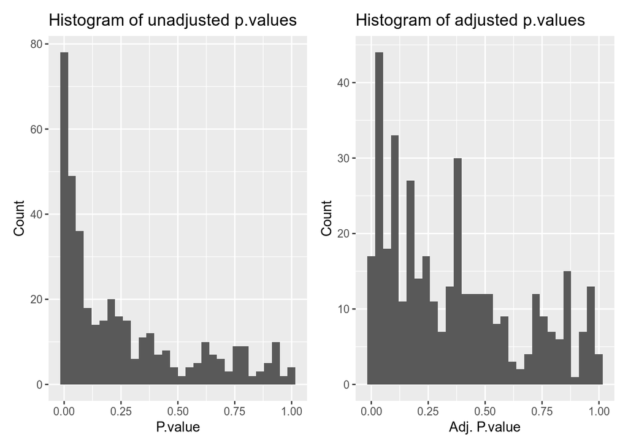

### Exercise 4.2

Make a volcano plot of the limma data.

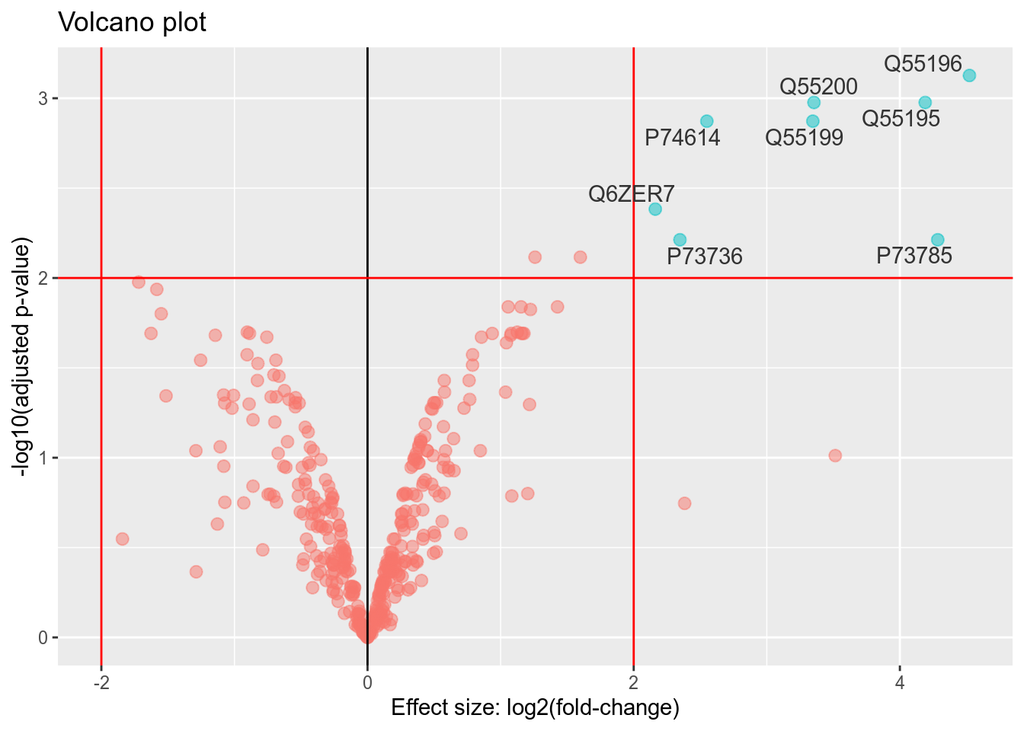

### Exercise 4.3

Finally print a table with all interesting proteins.

Proteins with adj P-value < 0.01 and absolute log ratio > 2

| protein | logFC | P.Value | adj.P.Val |
| --- | --- | --- | --- |
| Q55196 | 4.522796 | 0.0000019 | 0.0007467 |
| Q55200 | 3.354360 | 0.0000081 | 0.0010555 |
| Q55195 | 4.190257 | 0.0000081 | 0.0010555 |
| P74614 | 2.549630 | 0.0000147 | 0.0013412 |
| Q55199 | 3.345911 | 0.0000172 | 0.0013412 |
| Q6ZER7 | 2.162287 | 0.0000637 | 0.0041392 |
| P73736 | 2.347517 | 0.0001217 | 0.0061272 |
| P73785 | 4.284543 | 0.0001257 | 0.0061272 |

## Export

T-test results were exported to ./data/processed/proteomics/20200305_proteomics_ttest.csv

Limma results were exported to ./data/processed/proteomics/20200305_proteomics_limma.csv